# TP 2 : Simulation de lois de probabilités

Comparer les graphiques des échantillons *nd1*, *nd4* et *nd5* : qu’est-ce qui change ?

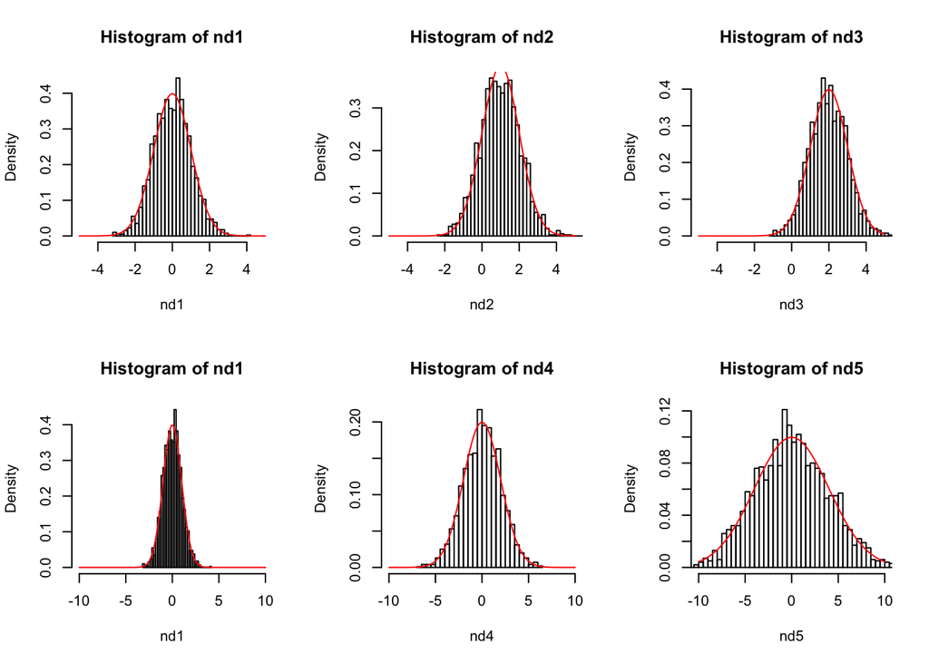

```r
##########################
# QUESTION 3
##########################
# On trace plusieurs histogrammes pour comparer la répartition des valeurs
par(mfrow=c(2,3))   # 6 graphes dans une seule fenetre
                    # sur 2 lignes et 3 colonnes

infx<- -5           # valeur min sur l'axe des x
supx<- 5            # valeur max sur l'axe des x
x<-seq(infx,supx,0.1) # creation d'un vecteur du min au max par pas de 0.1

hist(nd1,freq=FALSE,breaks=40,xlim=c(infx,supx))
lines(x,dnorm(x,0,1),col="red") # on ajoute a l'histogramme des valeurs
                                # la courbe theorique de la densite

hist(nd2,freq=FALSE,breaks=40,xlim=c(infx,supx))
lines(x,dnorm(x,1,1),col="red")
hist(nd3,freq=FALSE,breaks=40,xlim=c(infx,supx))
lines(x,dnorm(x,2,1),col="red")

# seconde ligne de graphiques
infx<- -10
supx<- 10
x<-seq(infx,supx,0.1)
hist(nd1,freq=FALSE,breaks=40,xlim=c(infx,supx))
lines(x,dnorm(x,0,1),col="red")
hist(nd4,freq=FALSE,breaks=40,xlim=c(infx,supx))
lines(x,dnorm(x,0,2),col="red")
hist(nd5,freq=FALSE,breaks=40,xlim=c(infx,supx))
lines(x,dnorm(x,0,4),col="red")
```

**Question 4 :** on veut maintenant comparer les fonctions de répartition des $5$ échantillons. La fonction *plot(ecdf(x))* permet de tracer la fonction de répartition empirique associée aux valeurs du vecteur *x*. Lancer les commandes de la question 4; sur chaque fonction de répartition empirique (en noir) on trace la fonction de répartition théorique en rouge.

Comparer les graphiques des échantillons *nd1*, *nd2* et *nd3* : qu’est-ce qui change ?

Comparer les graphiques des échantillons *nd1*, *nd4* et *nd5* : qu’est-ce qui change ?

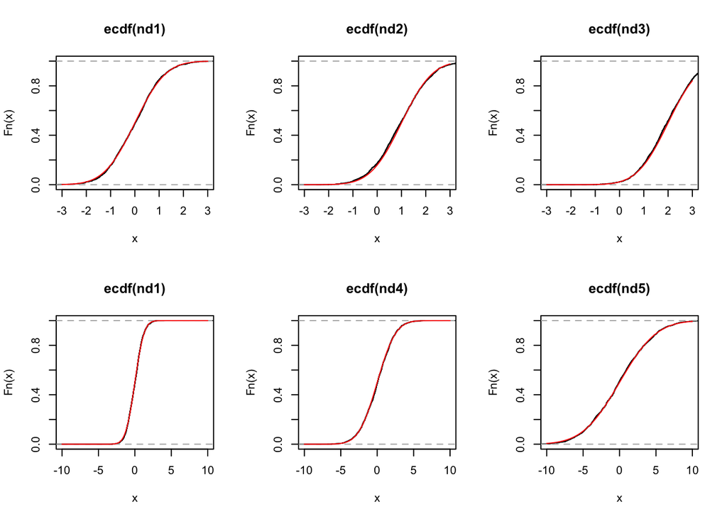

```r
##########################
# QUESTION 4
##########################
# On trace les fonctions de répartition des différents
# échantillons pour comparer la répartition des valeurs
par(mfrow=c(2,3))
infx<- -3
supx<- 3
x<-seq(infx,supx,0.1)
plot(ecdf(nd1),xlim=c(infx,supx))
lines(x,pnorm(x,0,1),col="red")
plot(ecdf(nd2),xlim=c(infx,supx))
lines(x,pnorm(x,1,1),col="red")
plot(ecdf(nd3),xlim=c(infx,supx))
lines(x,pnorm(x,2,1),col="red")
infx<- -10
supx<- 10
x<-seq(infx,supx,0.1)
plot(ecdf(nd1),xlim=c(infx,supx))
lines(x,pnorm(x,0,1),col="red")
plot(ecdf(nd4),xlim=c(infx,supx))
lines(x,pnorm(x,0,2),col="red")
plot(ecdf(nd5),xlim=c(infx,supx))
lines(x,pnorm(x,0,4),col="red")
```

```r
par(mfrow=c(1,1))
```

**Question 5 :** on veut montrer le lien entre la densité et la fonction de répartition.

Donner ci-dessous la densité de la loi normale de moyenne $0$ et de variance $1$ :

$$f(x)=$$
Quel est le lien entre la densité et la fonction de répartition ?

$$f(x)=$$
$$F(t)=$$

La valeur au point $t$ de la fonction de répartition (théorique) $F(t)$ d’une loi gaussienne de moyenne $m$ et d’écart-type $s$ est donnée par la commande *pnorm(t,m,s)* de R.

Lancer le script de la question 5 et décrire ce qu’il permet d’observer.

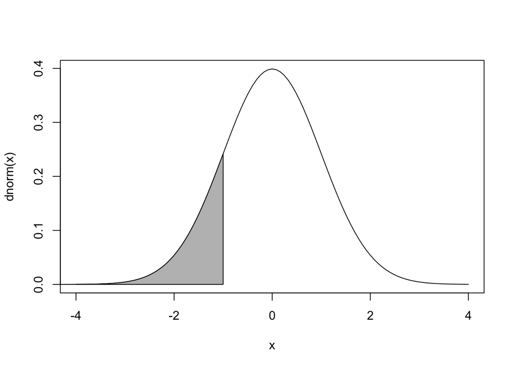

```r
##########################
# QUESTION 5
##########################
curve(dnorm,from=-4,to=+4)
# creation d'une fonction pour colorier l'aire sous la courbe d'une
# fonction <fun> entre <xmin> et <xmax>
shade_under_curve <- function(fun, xmin, xmax, length=100){
  xvals <- seq(xmin, xmax, length=length)
  dvals <- match.fun(fun)(xvals)
  polygon(c(xvals,rev(xvals)),c(rep(0,length),rev(dvals)),col="gray")
}
shade_under_curve(dnorm,-5,-1)
```

```r
##### valeur de l'aire sous la courbe
integrate(dnorm,-Inf,-1)
```

```
## 0.1586553 with absolute error < 4.8e-07
```

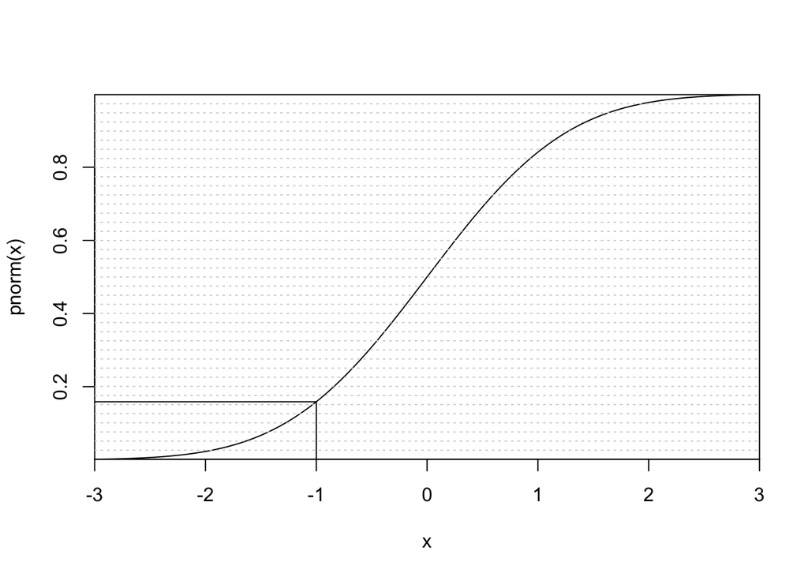

```r
##### valeur de F(-1) à lire sur le graphe
curve(pnorm,from=-3,to=3,xaxs="i",yaxs="i")
grid(NA,40,lwd=1)
segments(-1,0,-1,pnorm(-1))
segments(-1,pnorm(-1),-3,pnorm(-1))
```

```r
##### valeur de F(-1) par la fonction pnorm
pnorm(-1)
```

```
## [1] 0.1586553
```

**Question 6 :** on a tracé ci dessous la courbe de densité d’une loi gaussienne centrée (de moyenne 0) et de variance $4$ et l’on a hachuré différentes aires sous la courbe.

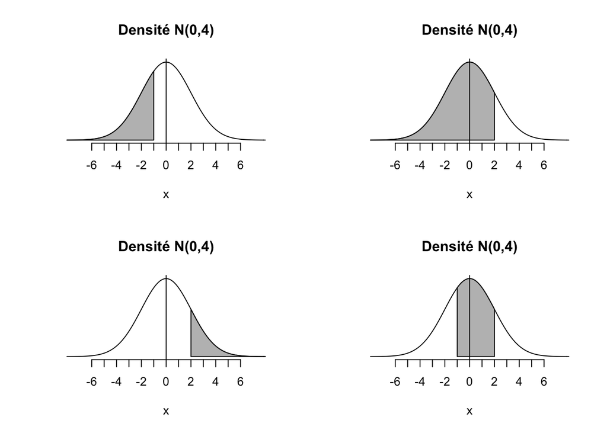

```r
par(mfrow=c(2,2))
N04<-function(x) dnorm(x,0,2)
curve(N04,from = -8,to = 8,ylab="",axes=FALSE,main="Densité N(0,4)")
shade_under_curve(N04,-8,-1)
axis(1,xaxp=c(-6,6,12))
axis(2,pos=0,c(-1,1))

curve(N04,from = -8,to = 8,ylab="",axes=F,main="Densité N(0,4)")
shade_under_curve(N04,-8,2)
axis(1,xaxp=c(-6,6,12))
axis(2,pos=0,c(-1,1))

curve(N04,from = -8,to = 8,ylab="",axes=F,main="Densité N(0,4)")
shade_under_curve(N04,2,8)
axis(1,xaxp=c(-6,6,12))
axis(2,pos=0,c(-1,1))

curve(N04,from = -8,to = 8,ylab="",axes=F,main="Densité N(0,4)")
shade_under_curve(N04,-1,2)
axis(1,xaxp=c(-6,6,12))
axis(2,pos=0,c(-1,1))
```

Compléter le tableau ci-dessous :

| Aire de la figure | Proba représentée par l’aire | Ecriture avec $F(t)$ | Valeur numérique pnorm |
| --- | --- | --- | --- |
| 1 | $P(X<-1)$ | $F(-1)$ |  |
| 2 |  |  |  |
| 3 |  |  |  |
| 4 |  |  |  |

**Question 6 :** soit $X$ une variable aléatoire gaussienne de moyenne $15$ et de variance $9$.

Quelle est la probabilité que $X\leq 17$ ? (utiliser la fonction *pnorm*)

Quelle est la probabilité que $X>7$ ? Enfin quelle est la probabilité que $7<X<15$ ?

## Lien entre lois normales

Soit $X$ une variable aléatoire distribuée suivant la loi normale d’espérance $0$ et d’écart-type $1$.

On souhaite montrer que les variables $X_1=X+1$, $X_2=X-1$, $X_3=2X$ et $X_4=X/2$ suivent aussi une loi normale. Pour cela on simule un grand nombre de valeurs suivant la loi normale $N(0,1)$ et l’on construit les nouvelles variables. Étudier la distribution de ces nouvelles variables.

```r
x<-rnorm(10000,0,1)
x1<-x+1
x2<-x-1
x3<-x*2
x4<-x/2
```

## Sommes de variables aléatoires gaussiennes

En vous aidant des résultats du script suivant, donner la loi de $X+Y$ et de $X-Y$ si $X\leadsto N(m_1,\sigma_1^2)$ et $Y\leadsto N(m_2,\sigma_2^2)$.

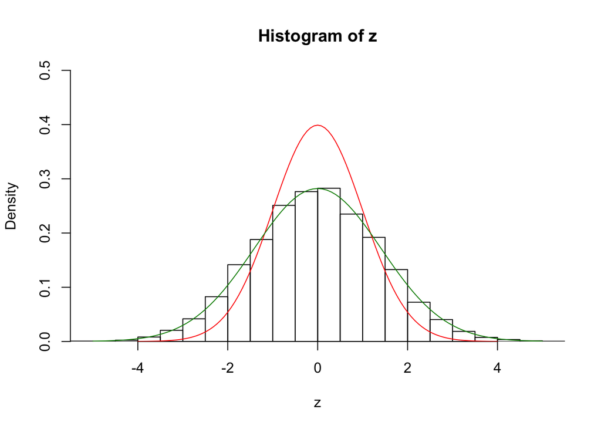

```r
old_par<-par()
par(xaxs="i",yaxs="i")

# Deux variables gaussiennes de m?me loi
x<-rnorm(10000,0,1)
y<-rnorm(10000,0,1)

z<-x+y
hist(z,breaks=20,freq=FALSE,ylim=c(0,0.5))
curve(dnorm,from= -4,to=4,add=TRUE,col="red") # la loi N(0,1)

x<-seq(-5,5,0.1)
lines(x,dnorm(x,0,sqrt(2)),col="green4") #la loi propos?e
```

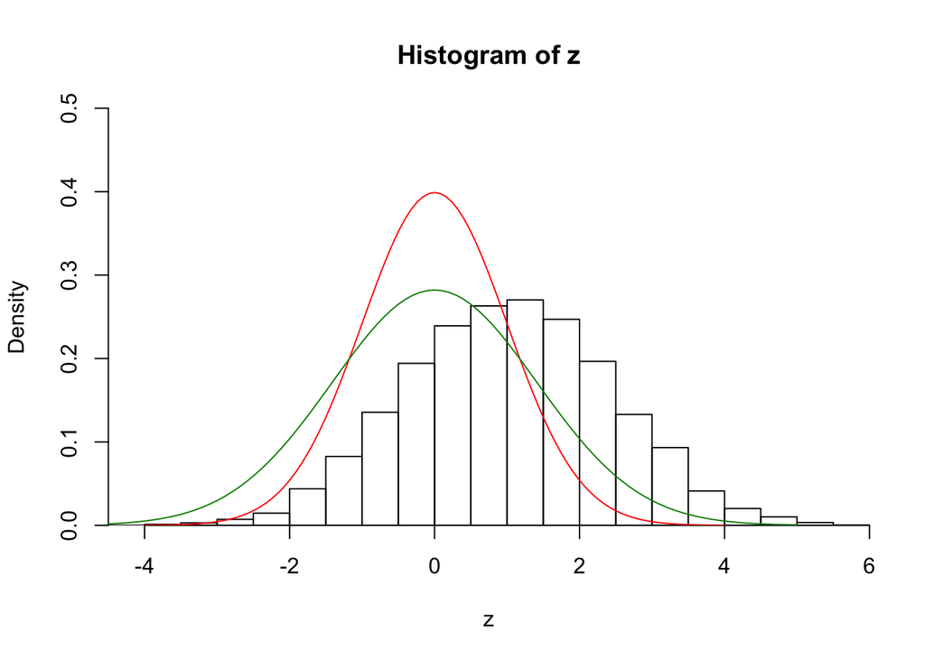

```r
# Deux variables gaussiennes de meme ecart type mais pas de meme esperance
x<-rnorm(10000,0,1)
y<-rnorm(10000,1,1)

z<-x+y
hist(z,breaks=20,freq=FALSE,ylim=c(0,0.5))
curve(dnorm,from= -4,to=4,add=TRUE,col="red") # la loi N(0,1)

x<-seq(-5,5,0.1)
lines(x,dnorm(x,0,sqrt(2)),col="green4") #la 1ere loi propos?e
```

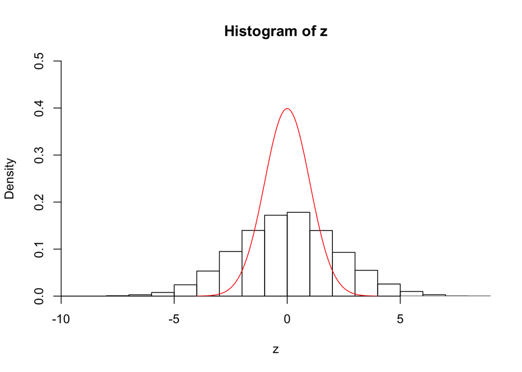

```r
x<-seq(-5,5,0.1)
#   lines(x,dnorm(x,###### a vous de trouver######),col="blue4") # la loi que vous proposez (pensez à décommentez la ligne...)

# Deux variables gaussiennes de meme esperance mais pas de meme ecart type
x<-rnorm(10000,0,1)
y<-rnorm(10000,0,2)

z<-x+y
hist(z,breaks=20,freq=FALSE,ylim=c(0,0.5))
curve(dnorm,from= -4,to=4,add=TRUE,col="red")
```

```r
x<-seq(-5,5,0.1)
#lines(x,dnorm(x,###### a vous de trouver######),col="green4") #la loi que vous proposez
```

$$X+Y\leadsto$$

$$X-Y\leadsto$$

Déduire de ce qui précède la loi de la variable $\bar{X}=\frac{1}{n}(X_1+X_2+X_3+...+X_n)$ où toutes les variables $X_i$ sont gaussiennes centrées réduites. Écrire un script pour l’illustrer.

```r
############################################################################
# Ecrire un script pour expliquer la loi d'une moyenne de lois gaussiennes #
############################################################################
```

## Somme de carrés de variables gaussiennes centrées réduites

Pour une somme de *carrés* de variables gaussiennes centrées réduites regarder la suite du script. Trouver le nom de la nouvelle loi des carrés et comment on choisit ses paramètres. (consulter l’aide de *R*)

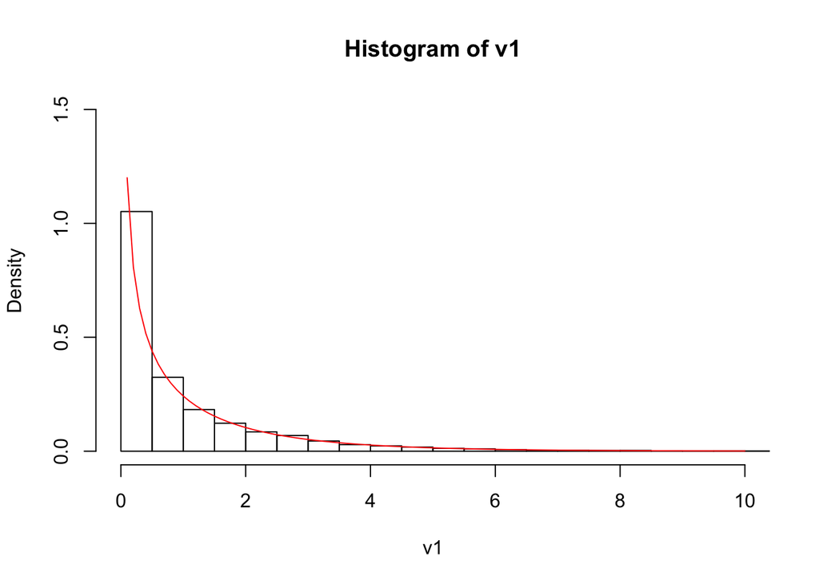

```r
#################################################################
## Somme des carrés de loi gaussiennes                        ###
#################################################################
v1<-rnorm(10000,0,1)^2
v2<-rnorm(10000,0,1)^2+rnorm(10000,0,1)^2
v3<-rnorm(10000,0,1)^2+rnorm(10000,0,1)^2+rnorm(10000,0,1)^2
v4<-rnorm(10000,0,1)^2+rnorm(10000,0,1)^2+rnorm(10000,0,1)^2+rnorm(10000,0,1)^2

hist(v1,breaks=40,prob=TRUE,xlim=c(0,10),ylim=c(0,1.5))
curve(dchisq(x,1),from= 0,to= 10,add=TRUE,col="red")
```

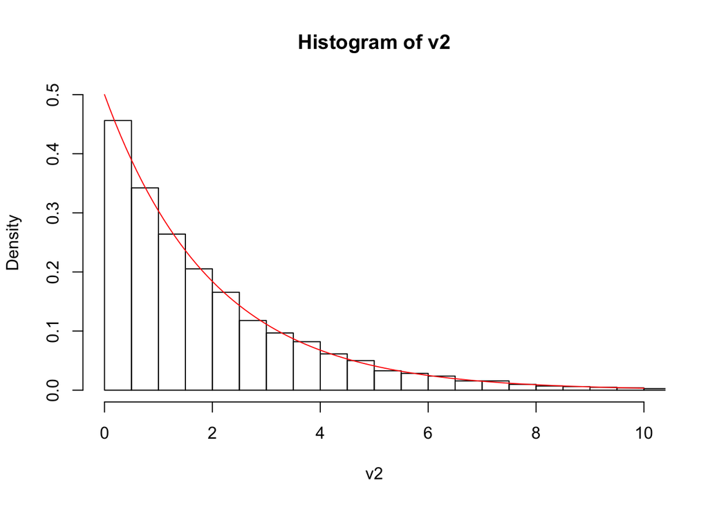

```r
hist(v2,breaks=40,prob=TRUE,xlim=c(0,10),ylim=c(0,0.5))
curve(dchisq(x,2),from= 0,to= 10,add=TRUE,col="red")
```

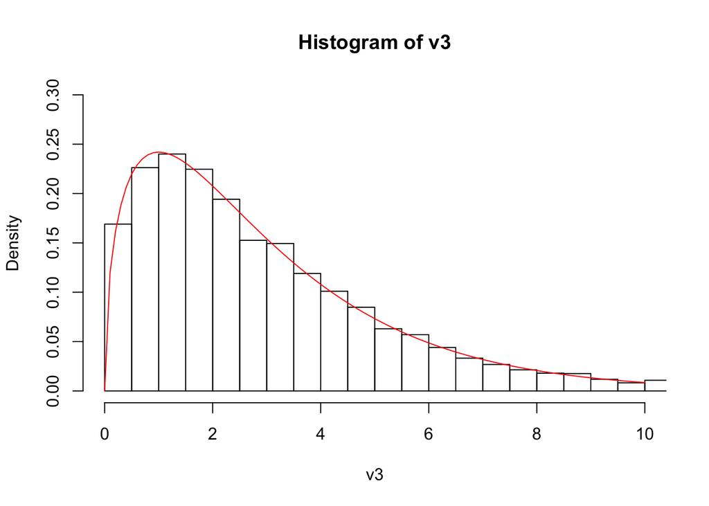

```r
hist(v3,breaks=40,prob=TRUE,xlim=c(0,10),ylim=c(0,0.3))
curve(dchisq(x,3),from= 0,to= 10,add=TRUE,col="red")
```

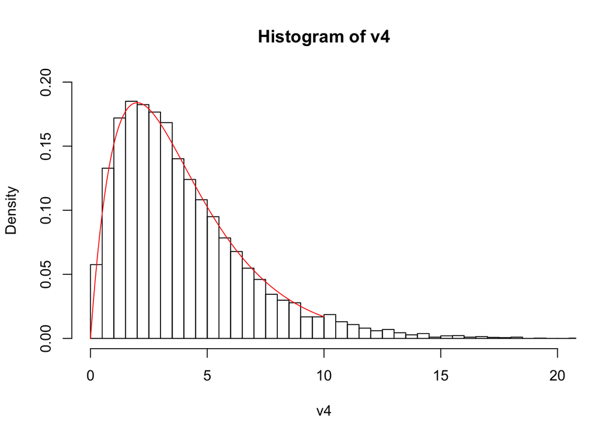

```r
hist(v4,breaks=40,prob=TRUE,xlim=c(0,20),ylim=c(0,0.20))
curve(dchisq(x,4),from= 0,to= 10,add=TRUE,col="red")
```

**Question : Etes-vous en mesure de compléter la formule ci-dessous ?**

$$X_1^2+X_2^2+X_3^2+...+X_n^2\leadsto$$

## Exercice

La taille $X$ d’un homme français tiré au sort dans la population est supposée suivre une loi normale de moyenne $172\,cm$ et de variance $196\,cm^2$ :

1. quelle est la probabilité que $X$ soit inférieure à $160\,cm$ ?
2. quelle est la probabilité qu’un homme tiré au sort mesure plus de deux mètres ?
3. Que vaut $P(165<X<185)$ ?
4. La taille des femmes françaises est modélisée par une loi gaussienne de moyenne $162\,cm$ et de variance $144\,cm^2$. Quelle est la probabilité qu’un homme tiré au sort soit plus grand qu’une femme choisie au hasard ?

## Loi Exponentielle

On dit que $X$ suit une loi exponentielle de paramètre $\lambda>0$, ce que l’on note $X\leadsto \mathcal E(\lambda)$ ssi sa fonction densité est :
$$\forall x\in \mathbb R,\,f(x)=\left \lbrace \begin{array}{cl}
\lambda \exp(-\lambda x) & \text{si } x \geq 0 \\
0 & \text {sinon}
\end{array}
\right.$$

**Question : Vérifier que $f$ est bien une fonction densité.**

La fonction de répartition de $X$ est
$$\forall x\in \mathbb R,\,F(x)= \int_{-\infty}^x f(t)\,dt = \left \lbrace \begin{array}{cl}
1- \exp(-\lambda x) & \text{si } x \geq 0 \\
0 & \text {sinon}
\end{array}
\right.$$

L’espérance d’une loi exponentielle est
$$\mathbb E[X] = \int_{-\infty}^{+\infty} xf(x)\,dx = \frac 1\lambda$$
Le moment d’ordre 2 d’une loi exponentielle est
$$\mathbb E[X^2] = \int_{-\infty}^{+\infty} x^2f(x)\,dx =\frac{2}{\lambda^2}$$
et donc la variance vaut
$$\mathbb V[X] = \mathbb E[X^2] - \mathbb E[X]^2 = \frac{1}{\lambda^2}$$

On peut mettre en oeuvre cela en R

```r
n <- 30              # taille de l'échantillon
lambda <- 10^{-3}    # paramètre de la loi exponentielle
ech<- rexp(n,rate = lambda)
mean(ech)
```

```
## [1] 1182.928
```

```r
var(ech)
```

```
## [1] 1543949
```

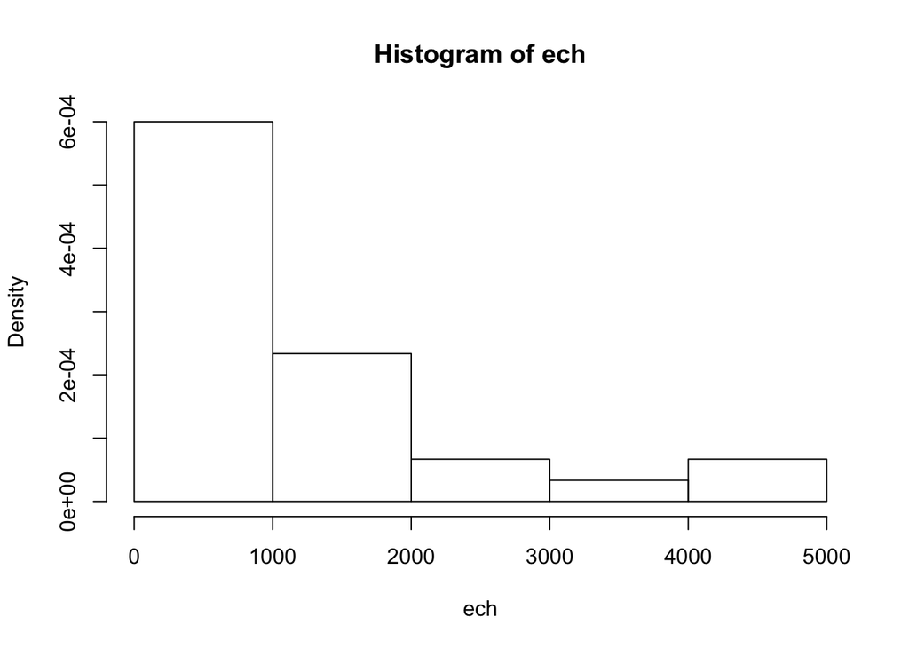

```r
hist(ech,freq=F)
```

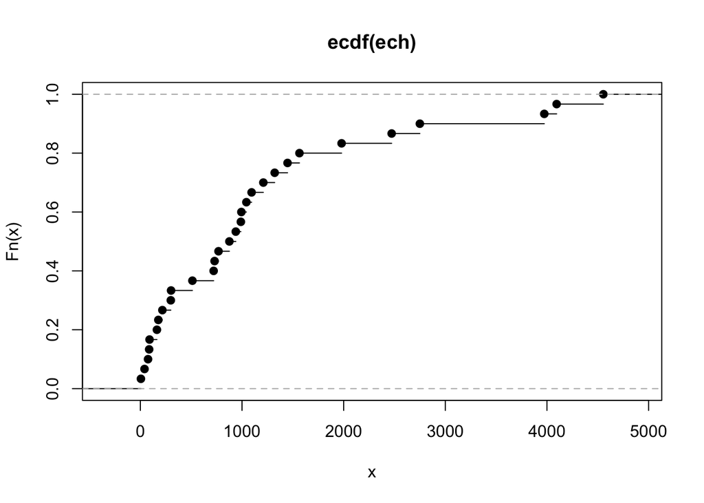

```r
plot(ecdf(ech))
```